# Aula prática - Biblioteca Networkx para grafos

A biblioteca NetworkX é um pacote python para a criação, manipulação e o estudo de estruturas, dinâmica e funções de grafos/redes complexas.

Neste tutorial aprenderemos o básico. Para começar é necessário instalar o networkx através do comando **pip install networkx**

## Criação de grafos

```python
import networkx as nx

G = nx.Graph()
```

Por definição, um grafo é uma coleção de nós (vertices) junto com pares de vértices, chamados arestas. Usando NetworkX, nós podem ser quaisquer objetos indexáveis, por exemplo: strings de texto, uma imagem, um objeto XML, outro grafo,..., dentre outros.

## Nós (vértices)

```python
#Adicionando um único vértice
G.add_node(1)

#Adicionando vários vértices de uma vez (através de uma lista)
G.add_nodes_from([2,3])

#Até agora criamos 3 nós
G.nodes()
```

```
[1, 2, 3]
```

```python
#Podemos adicionar os nós de outro grafo em nosso grafo
H=nx.path_graph(10)

H.nodes()
#H.edges()
```

```
[0, 1, 2, 3, 4, 5, 6, 7, 8, 9]
```

```python
G.add_nodes_from(H)

G.nodes()
```

```
[0, 1, 2, 3, 4, 5, 6, 7, 8, 9]
```

```python
#Também podemos por H como um vértice de G
G.add_node(H)

G.nodes()
```

```
[0,
 1,
 2,
 3,
 4,
 5,
 6,
 7,
 8,
 9,
 <networkx.classes.graph.Graph at 0x7f37d196d650>]
```

```python
#Podemos ver a quantidade de nós e arestas em nosso grafo G
G.number_of_nodes()
```

```
11
```

## Arestas

```python
#Adicionando uma aresta por vez
G.add_edge(1,2)
e=(2,3)
G.add_edge(*e) # unpack edge tuple

G.edges()
```

```
[(1, 2), (2, 3)]
```

```python
#Adicionando uma lista de arestas
G.add_edges_from([(1,2),(1,3)])

#Podemos adicionar as arestas de H
G.add_edges_from(H.edges())

G.edges()
```

```
[(0, 1),
 (1, 2),
 (1, 3),
 (2, 3),
 (3, 4),
 (4, 5),
 (5, 6),
 (6, 7),
 (7, 8),
 (8, 9)]
```

```python
G.number_of_edges()
```

```
10
```

```python
#Podemos ver a vizinhanhança de um grafo
G.neighbors(1)
```

```
[0, 2, 3]
```

## Remoção de vértices e Arestas

Podemos usar diversos métodos: Graph.remove_node(), Graph.remove_nodes_from(), Graph.remove_edge() and Graph.remove_edges_from()

```python
G.remove_node(H)

G.nodes()
```

```
[0, 1, 2, 3, 4, 5, 6, 7, 8, 9]
```

```python
'''
Nao ha problemas em adicionar arestas ou vértices existentes, por exemplo, depois de
remover todos os nos e arestas
'''
G.clear()

G.edges()
```

```
[]
```

```python
'''
Podemos adicionar novos vértices/arestas e o networkX ira ignorar qualquer uma que
já estiver presente
'''
G.add_edges_from([(1,2),(1,3)])
G.add_node(1)
G.add_edge(1,2)
G.add_node("spam") # adds node "spam"
G.add_nodes_from("spam") # adds 4 nodes: ’s’, ’p’, ’a’, ’m’

G.nodes()
```

```
['a', 1, 2, 3, 'spam', 'm', 'p', 's']
```

```python
#Podemos ver a vizinhanhança de um grafo
G.neighbors(1)
```

```
[2, 3]
```

```python
#Vamos remover todos os nós 's','p','a' e 'm'
G.remove_nodes_from("spam")
G.nodes()
```

```
[1, 2, 3, 'spam']
```

```python
#Removeremos a aresta 1 e 3 também
G.remove_edge(1,3)
G.edges()
```

```
[(1, 2)]
```

```python
#Podemos criar agora diferentes tipos de grafos

H=nx.DiGraph(G) # create a DiGraph using the connections from G
H.edges()
```

```
[(1, 2), (2, 1)]
```

```python
edgelist=[(0,1),(1,2),(2,3)]
H=nx.Graph(edgelist)
H.edges()
```

```
[(0, 1), (1, 2), (2, 3)]
```

## Adicionando atributos nas arestas

Atributos como pesos, labels, cores, até mesmo objetos python, podem ser atribuidos a grafos, vértices e arestas

### Atributos em um grafo

```python
G.clear();

G = nx.Graph(day="Friday")
G.graph
```

```
{'day': 'Friday'}
```

```python
#Alterando um atributo
G.graph['day'] = 'monday'
G.graph
```

```
{'day': 'monday'}
```

### Atributos em vértices

```python
G.add_node(1, time='5pm')
G.add_nodes_from([3], time='2pm')
G.node[1]
#G.node[3]
```

```
{'time': '5pm'}
```

```python
#Adicionar outro atributo a um vértice
G.node[1]['room'] = 714
G.nodes(data = True)
```

```
[(1, {'room': 714, 'time': '5pm'}), (3, {'time': '2pm'})]
```

```python
G.node[1]['room']
```

```
714
```

### Atributos em arestas

```python
G.add_edge(1, 2, weight=4.7 )
G.add_edges_from([(3,4),(4,5)], color='red')
G.add_edges_from([(1,2,{'color':'blue'}), (2,3,{'weight':8})])
G[1][2]['weight'] = 4.7
G.edge[1][2]['weight'] = 4
```

```python
G.edges(data=True)
```

```
[(1, 2, {'color': 'blue', 'weight': 4}),
 (2, 3, {'weight': 8}),
 (3, 4, {'color': 'red'}),
 (4, 5, {'color': 'red'})]
```

Existem Diversas outras funcionalidades... [Clique aqui para ver mais](https://networkx.github.io/documentation/networkx-1.9/_downloads/networkx_tutorial.pdf)

## Visualizando Grafos

```python
%matplotlib inline
#Usaremos networkx combinada a matplotlib para isso
import matplotlib.pyplot as plt
```

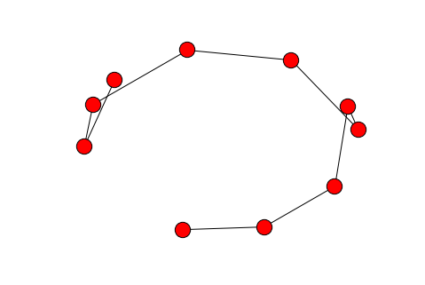

```python
G = nx.path_graph(10)
nx.draw(G)
#nx.draw_random(G)
#nx.draw_circular(G)
#nx.draw_spectral(G)


plt.show();
```

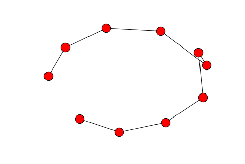

```python
#Para salvar a figura use

nx.draw(G)
plt.savefig("ex.png")
```

```python
nodecolor = list()
for i in range(G.number_of_nodes()):
    if (i % 2 == 0):
        G.node[i]['color']='b'
        nodecolor.append('b')
    else:
        G.node[i]['color']='r'
        nodecolor.append('r')

G.nodes(data=True)
```

```
[(0, {'color': 'b'}),
 (1, {'color': 'r'}),
 (2, {'color': 'b'}),
 (3, {'color': 'r'}),
 (4, {'color': 'b'}),
 (5, {'color': 'r'}),
 (6, {'color': 'b'}),
 (7, {'color': 'r'}),
 (8, {'color': 'b'}),
 (9, {'color': 'r'})]
```

```python
nodecolor
```

```
['b', 'r', 'b', 'r', 'b', 'r', 'b', 'r', 'b', 'r']
```

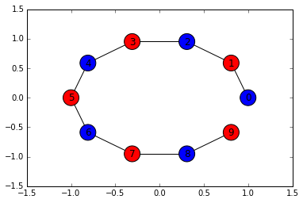

```python
#https://networkx.github.io/documentation/stable/reference/generated/networkx.drawing.nx_pylab.draw_networkx.html#networkx.drawing.nx_pylab.draw_networkx
nx.draw_networkx(G,pos = nx.circular_layout(G), with_labels=True,node_size=400, node_color=nodecolor)
```

# Exercício - Extra

Uma estrutura secundária (bidimensional) de uma sequência de RNA é de grande importância na área de bioinformática, pois auxilia na identificação de qual função tal molécula desempenha.

Uma sequência de RNA, extraída de um DNA é uma sequência de nucleotídeos do alfabeto = {a,c,t,g}, onde t pode ser substituído por u, caso seja um miRNA. Abaixo temos uma estrutura primária de uma sequência de RNA:

GGCUUCCUGGUACUUACCACAGUCUGUAUUCUUACACUGACUGUAUAGAAAGAGGAGGC

Sua estrutura secundária pode ser obtida de diversos métodos diferentes, por exemplo usando a ferramenta [RNAFold](http://rna.tbi.univie.ac.at/cgi-bin/RNAWebSuite/RNAfold.cgi). A resposta deste algoritmo é uma representação da estrutura secundária denominada *Dot-bracked Notation*:

```
GGCUUCCUGGUACUUACCACAGUCUGUAUUCUUACACUGACUGUAUAGAAAGAGGAGGC
```

```
.(((((((....((....((((((((((....))))..))))))..))....)))))))
```

[figure not shown]

Note que essa representação pode ser visualizada como um grafo...

**1)** A partir de uma entrada composta de duas strings: a sequência de RNA e a notação em parênteses (Dot-bracked Notation), crie um programa que exiba uma representação em grafos de sua estrutura secundária correspondente. Obs.: A entrada pode ser feita diretamente no código fonte:

```
 seq  = GGCUUCCUGGUACUUACCACAGUCUGUAUUCUUACACUGACUGUAUAGAAAGAGGAGGC
```

```
 dbn  = .(((((((....((....((((((((((....))))..))))))..))....)))))))
```

Já a saída deve ser uma imagem no formato .png.

**2)** A partir de 1), altere o código para que os loops internos sejam coloridos de cor diferente do restante da estrutura secundária. Loops internos são porções não pareadas que estão dentro de stems (regiões pareadas contíguas).